# STAT340 Discussion 3: Monte Carlo

## XKCD comic

[figure not shown]

Complete these in your discussion groups. One submission per group. **Choose 2** of the following exercises to complete.

## 1. Estimating Robbin’s constant

[Robbin’s constant](https://mathworld.wolfram.com/CubeLinePicking.html) is the mean distance between two points in a cube.

1. Randomly generate two points $(x_1,y_1,z_1)$, $(x_2,y_2,z_2)$ **uniformly** in the unit cube a total of $N$ times (at least $1000$, but the more the better!)
   - hint: you can easily generate all the coordinates you need at once with `runif(6*N)`, then [reshape](https://stackoverflow.com/questions/17752830/r-reshape-a-vector-into-multiple-columns) to an $N\times 6$ matrix (one column for each coordinate component, with each row representing a pair of points), and then perform the arithmetic in the next step by using vectorized operations on the columns (i.e., using each column all at once) to improve computational efficiency.
   - if you are having difficulties with the above, you can always use the simpler approach of running a for loop N times, where in each step of the loop you generate 2 points (6 coordinates total) and then perform the arithmetic in the next step. For-loops in R tend to be slower than vectorized operations, though!
2. Next, compute the standard [Euclidean distance](https://en.wikipedia.org/wiki/Euclidean_distance#Higher_dimensions) between each pair of points and find the mean distance. (Bonus: plot the distribution of these distances!)

```r
# Define a function for generating two points and computing their distance
run_experiment <- function() {
  x <- runif(n=3,min=0,max=1)
  y <- runif(n=3,min=0,max=1)
  # x and y are 3-vectors.
  # Return their squared distance
  # Remember, Euclidean distance is the square root of the
  # sum of the squares of the entries of a vector.
  return( sqrt( sum( (x-y)^2 ) ) )
}

# Now, for each MC trial, run the experiment and record the distance
NMC <- 1000;
distances <- rep(NA, NMC);
for(i in 1:NMC) {
  distances[i] <- run_experiment()
}

robbins_estimate <- mean( distances )
robbins_estimate
```

```
## [1] 0.6655032
```

3. Calculate your [percentage error](https://www.mathsisfun.com/numbers/percentage-error.html) from the [true value](https://stat.ethz.ch/R-manual/R-devel/library/base/html/Constants.html).

```r
robbins_true <- 0.661707182095901;
abs(robbins_estimate - robbins_true)/robbins_true
```

```
## [1] 0.005736685
```

4. **Bonus:** can you increase the accuracy of your estimation by using more points (i.e., increasing $N$)? How low can you get the error?

```r
NMC <- 1e5; # Cranking up MC iterates by two orders of magnitude
distances <- rep(NA, NMC);
for(i in 1:NMC) {
  distances[i] <- run_experiment()
}

robbins_estimate <- mean( distances )
abs(robbins_estimate - robbins_true)/robbins_true
```

```
## [1] 0.0006378065
```

5. **Super bonus:** Repeat the above for another 2D or 3D object of your choice (how about a triangle or a sphere?)

```r
#Random point in a sphere - the simple way (try points in the cube until one is in the sphere)
#sphere with radius 1 centered at origin
get_sphere_point <- function(){
  repeat{
    x<-runif(3,-1,1)
    if(sum(x^2)<=1) break
  }
  return(x)
}

random_distance <- function (){
  x <- get_sphere_point()
  y <- get_sphere_point()
  return(sqrt(sum((x-y)^2)))
}

# Now, for each MC trial, run the experiment and record the distance
NMC <- 1000;
distances <- rep(NA, NMC);
for(i in 1:NMC) {
  distances[i] <- random_distance()
}

robbins_estimate <- mean( distances )
robbins_estimate
```

```
## [1] 1.054492
```

```r
#actual mean distance is 36/35
robbins_true <- 36/35
abs(robbins_estimate - robbins_true)/robbins_true
```

```
## [1] 0.02520027
```

## 2. Flipping coins

Suppose you flip a fair coin $N$ times. How many heads in a row should you expect to see? For example, suppose that I flip a coin 20 times, and I get 5 heads in a row at some point in the sequence. Is this a “surprising” outcome?

1. Write code to simulate randomly flipping a fair coin ($p=0.5$) a total of $N=10$ times (hint: use either the `rbernoulli` function from the `purrr` package or `rbinom` with `n=10` and `size=1`) and record how many heads (defined as a value of $1$; tails is $0$) in a row you observe. Determining the length of the longest run has been implemented in the function `longest_head_run` below.
2. Repeat the above experiment $M$ times. Set $M$ to be at least $1000$, but don’t make it extremely large, because we are going to repeat the previous step for other values of the number of flips $N$. What is the mean length of the largest run of heads in $N=10$ flips?
   - **Note:** $N$ here is the *size of each experiment*. That is, each experiment consists of $N$ flips. On the other hand, $M$ is *how many experiments* are performed (i.e., the number of times we repeat the experiment). It is common when using Monte Carlo methods to have two types of parameters: one type for the properties of each experiment (e.g., $N$, in this case), and one type that determines how many experiments are done (here, $M$). Increasing $N$ (number of flips in each experiment) will change the experiment by increasing the mean-run-length, whereas increasing $M$ (the number of experiments) will increase the precision of the estimate of the mean run length for a particular number of flips $N$.
3. Now, repeat the above (you may use the same $M$) for *at least 3* other values of $N$ (again, feel free to do more if you wish!). Display your results in a table.
   - **Note:** this step should be easy if you’ve written your code with good style. I recommend writing a function that does all the above for any given $N$ and $M$ and, optionally, $p$. For example, something like `find_mean_run <- function(N, M, p = 0.5) {......}`. Then, for different values of $N$ and $M$ you can simply change the arguments given to the function, e.g. `find_mean_run(10, 1000)` or `find_mean_run(20, 1000)`, etc., then put them in a data frame.
   - **Note:** the above function syntax sets `N` and `M` as arguments to the function without default values, but sets `0.5` as the default value of the argument `p`. For a different example, [see this](https://www.javatpoint.com/r-function-default-arguments).
4. Validate your results against other people’s results (for example, [this post](https://math.stackexchange.com/a/1409539)). Are your results consistent with others?
5. **Bonus:** run a few more values of $N$ and plot the results, showing the mean run length as a function of the number of flips $N$. (bonus²: what happens if you increase $M$?)
6. **Super bonus:** Like [the post referenced above](https://math.stackexchange.com/questions/1409372/what-is-the-expected-length-of-the-largest-run-of-heads-if-we-make-1-000-flips/1409539#1409539), can you fit a smooth curve through the points?

```r
# given output of rbernoulli or rbinom (a vector of 0's and 1's)
# compute the length of the longest continuous run of 1's
longest_head_run <- function(trials) {
  rle_encoded <- rle(trials)
  head_sequence_indicators <- rle_encoded$values == 1

  if (!any(head_sequence_indicators)) {
    return(0L)
  }

  lengths_head_sequences <- rle_encoded$lengths[head_sequence_indicators]

  max(lengths_head_sequences)
}

# demo of using longest_head_run
longest_head_run(c(0, 0, 0, 0, 0, 0, 0, 0, 0, 0, 0, 0)) # returns 0
```

```
## [1] 0
```

```r
longest_head_run(c(1, 0, 1, 1, 0, 1, 1, 1, 0, 0, 0, 0)) # returns 3
```

```
## [1] 3
```

```r
# a) Write code to simulate randomly flipping a fair coin ($p=0.5$)
# a total of $N=10$ times (hint: use either the `rbernoulli` function
# from the `purrr` package or `rbinom` with `n=10` and `size=1`) and
# record how many heads (defined as a value of $1$; tails is $0$)
# in a row you observe.
flip_coins <- function() {
  flips <- rbinom(n=10, size=1, p=0.5);
  return( longest_head_run( flips ) );
}

#b. Repeat the above experiment $M$ times. Set $M$ to be at least $1000$,
# but don't make it extremely large, because we are going to repeat the
# previous step for other values of the number of flips $N$.
# What is the mean length of the largest run of heads in $N=10$ flips?
M <- 1e4;
run_lengths <- rep( 0, M );
for( i in 1:M ) {
  run_lengths[i] <- flip_coins()
}
mean( run_lengths )
```

```
## [1] 2.8274
```

```r
# Define a function to run the experiment for varying number of coins,
# number of MC replicates and
estimate_run_length <- function( n, M, p=0.5 ) {
  runs <- rep( 0, M );
  for( i in 1:M ){
    flips <- rbinom(n=n, size=1, p=p);
    runs[i] <- longest_head_run( flips );
  }
  return( mean(runs) )
}

estimate_run_length(20, 1e4, p=0.5)
```

```
## [1] 3.7231
```

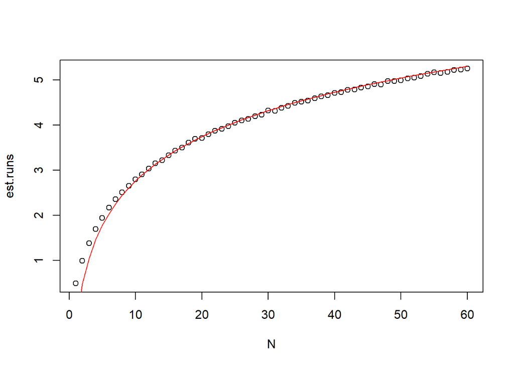

```r
##Super bonus
max_flips <- 60
N <- 1:max_flips
est.runs <- vector("numeric", max_flips)
for(n in N){
  est.runs[n] <- estimate_run_length(n, 1e4, p=.5)
}

plot(x=N, y=est.runs)

# an approximation can be found here https://math.stackexchange.com/questions/1409372/what-is-the-expected-length-of-the-largest-run-of-heads-if-we-make-1-000-flips

approx.L <- .983*log(x=.703*N, base=2)
lines(x=N, y=approx.L, col="red")
```

## 3. Simulating a $t$-distribution with $N-1$ degrees of freedom.

1. Choose an arbitrary $\mu$ and $\sigma>0$ to **use for the rest of the problem.** You may choose the standard normal $N(0,1)$ if you *really* wish, but where’s the fun in that?

```r
mu <- 3.14159;
sigma <- 2;
```

2. Start by sampling $N=2$ values from the normal distribution with mean $\mu$ and standard deviation $\sigma$ (note this counts as $1$ experiment) and calculate the $t$-statistic of your sample. Recall the $t$-statistic for a sample $X$ is defined as
   $$t=\frac{\overline{X}-\mu}{s/\sqrt{N}}~,~~~s=\sqrt{\frac{1}{N-1}\sum_{i=1}^{N}(X_i-\overline{X})^2}$$
   where $\overline{X}$ is the sample mean and $s$ is the [sample standard deviation](https://www.khanacademy.org/math/statistics-probability/summarizing-quantitative-data/variance-standard-deviation-sample/a/population-and-sample-standard-deviation-review). The R function `sd` will compute this for you. See `?sd`.

```r
tstat <- function(x, mu) {
  Xbar <- mean(x);
  s <- sd(x);
  N <- length(x);
  return( (Xbar-mu)/(s/sqrt(N)) );
}
normals <- rnorm(2, mean=mu, sd=sigma);
tstat(normals, mu)
```

```
## [1] -0.02496699
```

[output not shown]

3. Repeat the above step $M$ times (similar to exercise 2b, use at least $1000$ times, but don’t use an extremely large $M$ since we will repeat this for other values of $N$).

```r
M <- 1e4;
simulated_t <- vector( "numeric", M );
for(i in 1:M) {
  x <- rnorm(n=2, mean=mu, sd=sigma);
  simulated_t[i] <- tstat(x, mu)
}
```

4. You’ve just simulated drawing from a $t$-distribution with $N-1=1$ degree of freedom! Now plot the resultant values in a [density](https://www.r-graph-gallery.com/21-distribution-plot-using-ggplot2) plot.

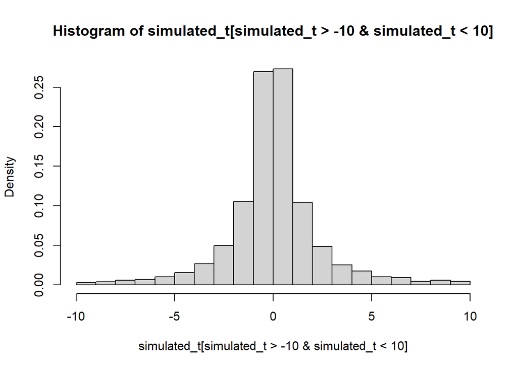

```r
#A few outliers make the histogram really awful. Let's plot from -10 to 10 only
hist(simulated_t[simulated_t > -10 & simulated_t < 10], probability=TRUE)
```

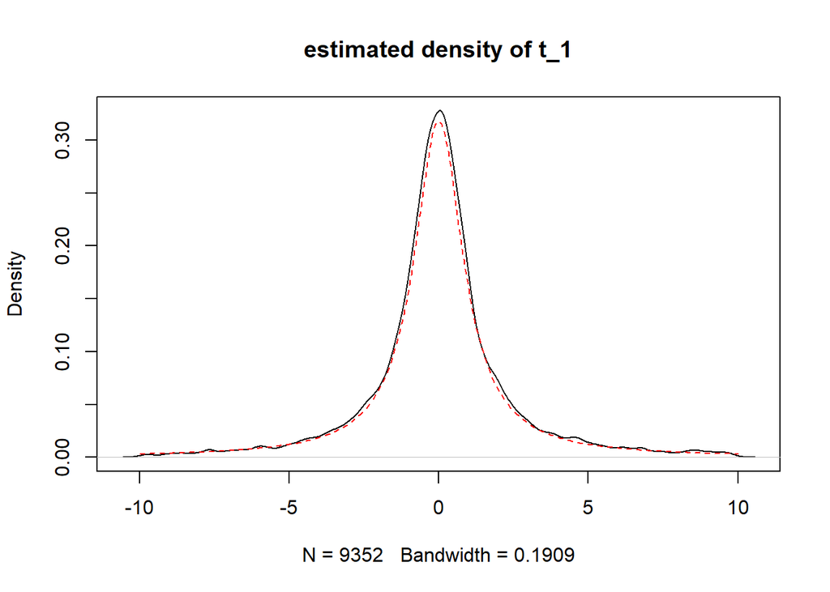

```r
#WE can also plot the estimated density of our data
plot(density(simulated_t[simulated_t > -10 & simulated_t < 10]), main="estimated density of t_1")
x=seq(-10,10,.1)
lines(x=x,y=dt(x,1), col="red",lty=2)
```

e. For comparison, plot the theoretical distribution with $1$ degree of freedom ([this page](https://t-redactyl.io/blog/2016/03/creating-plots-in-r-using-ggplot2-part-9-function-plots.html) may be helpful). For best results, overlay this on top of the previous plot, but if you’re having trouble with this, you can also plot them side-by-side. See `?dt` for the density of the $t$-distribution in R.

6. Repeat the above steps for *at least 3* other values of $N$ (for example 3, 6, 11, but feel free to choose your own or choose more than 3!). For each $N$, plot both your simulated distribution and the theoretical distribution.

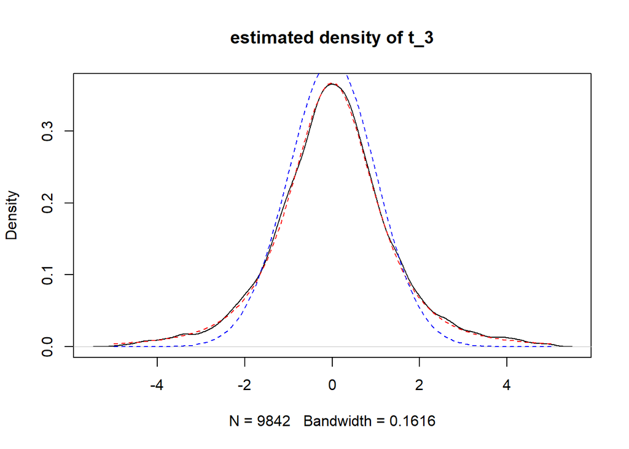

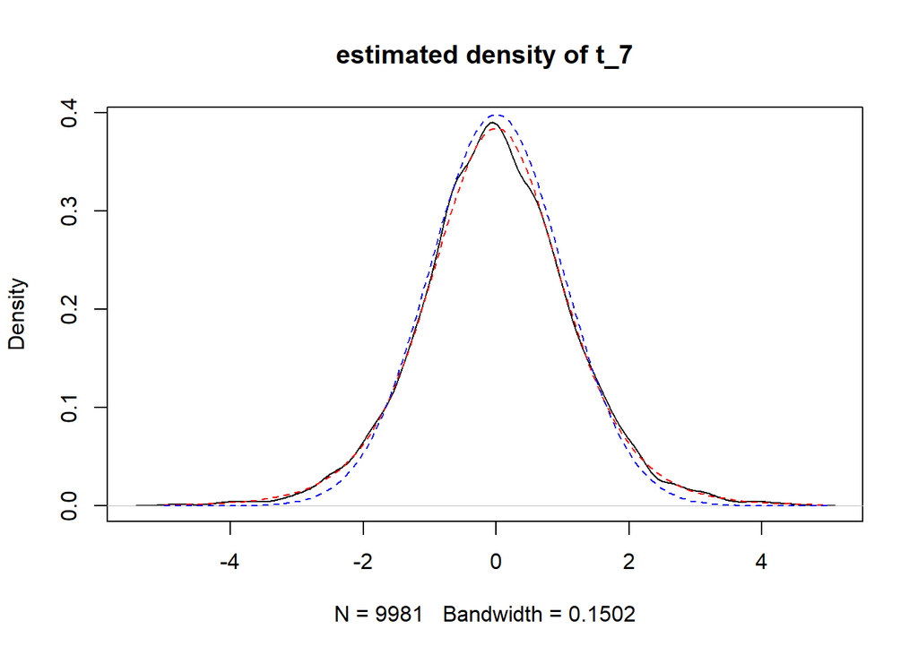

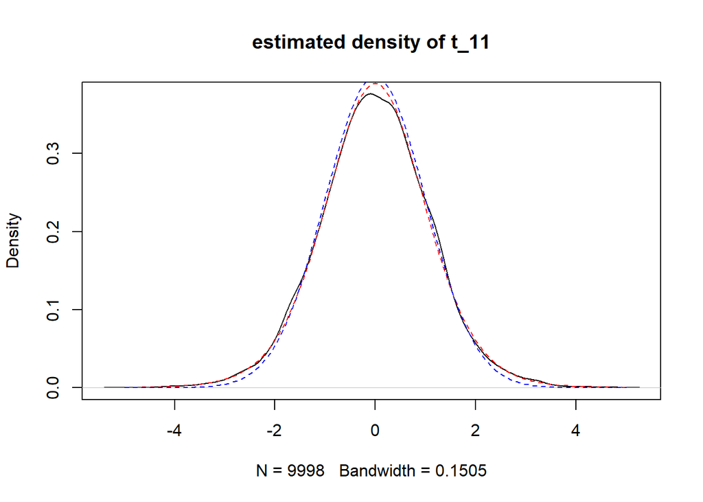

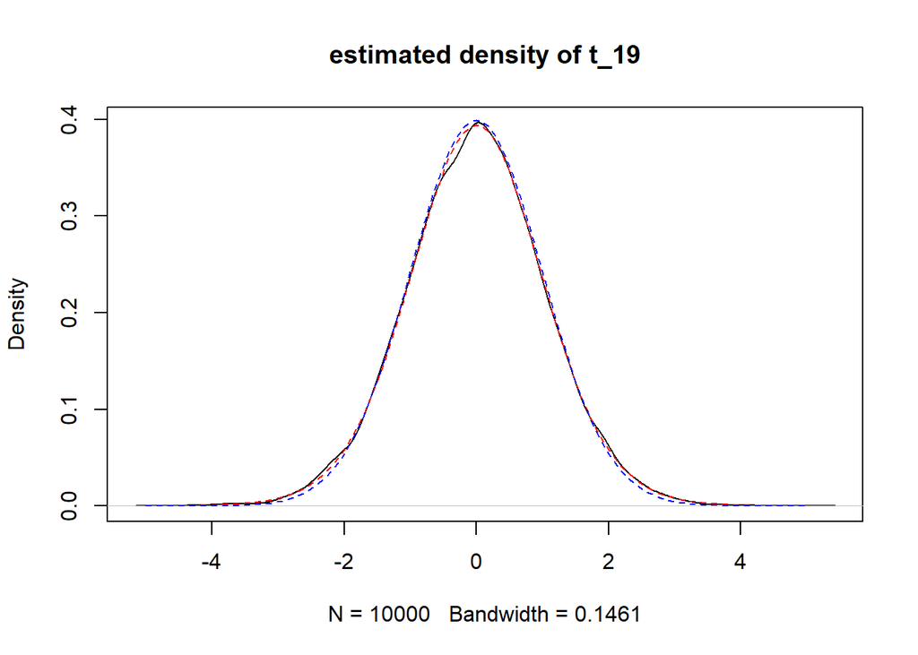

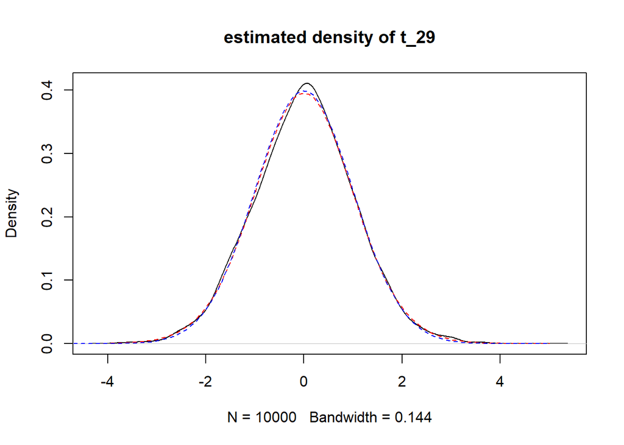

```
  - __Note:__ again, like the note in exercise 2c, this should be easy if you used a function!
```

```r
#In blue I've plotted the standard normal distribution
#In red there's the theoretical t distribution
Ns <- c(4,8, 12,20, 30)
for(n in Ns){
  M <- 1e4;
  simulated_t <- vector( "numeric", M );
  for(i in 1:M) {
    x <- rnorm(n=n, mean=mu, sd=sigma);
    simulated_t[i] <- tstat(x, mu)
  }
  plot(density(simulated_t[simulated_t > -5 & simulated_t < 5]), main=paste("estimated density of t_",(n-1), sep=""))
  x=seq(-5,5,.1)
  lines(x=x,y=dt(x,n-1), col="red",lty=2)
  lines(x=x,y=dnorm(x), col="blue",lty=2)
}
```

7. **Bonus:** What do you notice about how the distribution changes as $N$ increases? What happens if you crank $N$ way up (e.g., to $N=100$ or $N=1000$)?

You should see that as $N$ increases, the data looks more and more like a normal distribution.